# Homework 3

Jacob Harrell

3/3/2021

**Question 1**

The dataset, as provided, includes the following variables:

1. y : this is the response variable wherein 1 represents a success and 0 represents a failure
2. x1 : this is a continuous predictor variable
3. x2 : this is a categorical variable represented as either ‘a’ or ‘b’

We can fit a logistic regression model to this data with the assumption that the probability of success is an additive function of both x1 and x2. It would look something like this:

```r
#setwd(choose.dir('hw3.csv'))
hw3<-read.csv(file='hw3.csv')

fit<- glm(y~x1+x2, family = binomial, data = hw3)
summary(fit)
```

```
##
## Call:
## glm(formula = y ~ x1 + x2, family = binomial, data = hw3)
##
## Deviance Residuals:
##      Min        1Q    Median        3Q       Max
## -1.43687  -1.00592   0.01992   1.00818   1.50526
##
## Coefficients:
##             Estimate Std. Error z value Pr(>|z|)
## (Intercept)   0.5948     0.3950   1.506   0.1321
## x1           -0.1680     0.3648  -0.460   0.6452
## x2b          -0.9679     0.4136  -2.340   0.0193 *
## ---
## Signif. codes:  0 '***' 0.001 '**' 0.01 '*' 0.05 '.' 0.1 ' ' 1
##
## (Dispersion parameter for binomial family taken to be 1)
##
##     Null deviance: 138.63  on 99  degrees of freedom
## Residual deviance: 132.59  on 97  degrees of freedom
## AIC: 138.59
##
## Number of Fisher Scoring iterations: 4
```

**Question 2**

To begin to interpret the effect of variable x1 on the log of success, we can first rewrite the linear model by plugging in the various coefficients, like so:

y[i] = 0.5948 - 0.1680 * x1 - 0.9679 * x2

Here, the value -.1680 refers to the ratio of log odds for success with relation to variable x1.

This can be verified through r by evaluating the log odds ratio of a 1-unit change within x1.

```r
beta<- coef(fit)
beta
```

```
## (Intercept)          x1         x2b
##   0.5948499  -0.1679760  -0.9679244
```

```r
p_1<-plogis(beta[1]+beta[2]*1)
p_1
```

```
## (Intercept)
##   0.6051269
```

```r
p_2<-plogis(beta[1]+beta[2]*2)
p_2
```

```
## (Intercept)
##   0.5643653
```

```r
log((p_2/(1-p_2))/(p_1/(1-p_1)))
```

```
## (Intercept)
##   -0.167976
```

From this, we can see that the slope coefficient for x1 is negatively related with the value of x1 and we thus have a lower probability of success as the value of x1 increases.

**Question 3**

The effects of variable x2 on the logs of success can be interpreted in a similar manner x1. This time, however, the variable x2 is a categorical variable.

And so, to verify this using r:

```r
p_b<-plogis(beta[1]+beta[3])
p_b
```

```
## (Intercept)
##   0.4077983
```

```r
p_a<-plogis(beta[1])
p_a
```

```
## (Intercept)
##   0.6444772
```

```r
log((p_b/(1-p_b))/(p_a/(1-p_a)))
```

```
## (Intercept)
##  -0.9679244
```

Once again, the slope coefficient of x2 is negatively related to the variable x2. Thus, there is a higher probability of success when the point falls within ‘a’ than when the point falls within ‘b’.

**Question 4**

The variable x1 will be examined first for the Wald Test and p-value.

```r
#Wald Test
ts1<-beta[2]/summary(fit)[['coefficients']]['x1', 'Std. Error']
ts1
```

```
##         x1
## -0.4604971
```

```r
#And to compare with the fitted model...
summary(fit)[['coefficients']]['x1','z value']
```

```
## [1] -0.4604971
```

```r
#And now, the p-value associated with x1...
px1<-2*pnorm(-1*abs(ts1), mean=0, sd=1)
px1
```

```
##        x1
## 0.6451594
```

```r
#And to compare with the fitted model...
summary(fit)[['coefficients']]['x1', 'Pr(>|z|)']
```

```
## [1] 0.6451594
```

The same procedure can be conducted for variable x2.

```r
#Wald Test
ts2<-beta[3]/summary(fit)[['coefficients']]['x2b', 'Std. Error']
ts2
```

```
##       x2b
## -2.340366
```

```r
#And to compare with the fitted model...
summary(fit)[['coefficients']]['x2b','z value']
```

```
## [1] -2.340366
```

```r
#And now, the p-value associated with x2...
px2<-2*pnorm(-1*abs(ts2), mean=0, sd=1)
px2
```

```
##        x2b
## 0.01926485
```

```r
#And to compare with the fitted model...
summary(fit)[['coefficients']]['x2b', 'Pr(>|z|)']
```

```
## [1] 0.01926485
```

**Question 5**

And now, predicting and plotting the mean probability of success over a range of values for x1.

```r
y<-beta[1]+beta[2]*mean(hw3$x1)+beta[3]

#Mean probability of success
exp(y)/(1+exp(y))
```

```
## (Intercept)
##   0.3765613
```

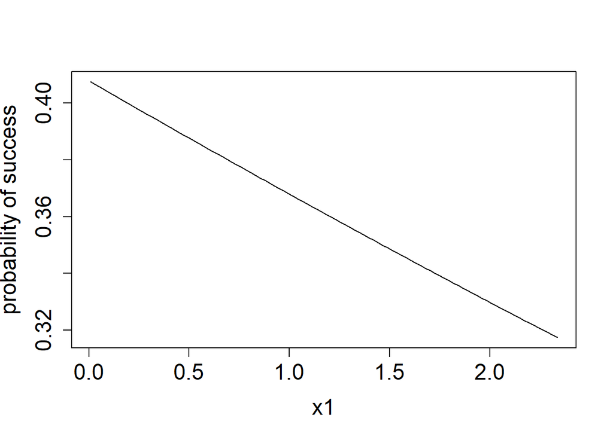

```r
x1<-seq(from=min(hw3$x1), to=max(hw3$x1), length.out=100)
y<-beta[1]+beta[2]*x1+beta[3]

plot(x=x1, y=plogis(y), ylab='probability of success', xlab='x1', cex.axis=1.5, cex.lab=1.5, type='l')
```